# scanpy-tutorial

```python
# Core scverse libraries
import scanpy as sc
import anndata as ad

# Data retrieval
import hisepy # original tutorial was import pooch
```

[output not shown]

These warnings are for docstrings.. should be safe to ignore but a little confused why they are popping up.

## Reading in the data

deviating a little here from [the tutorial](https://scanpy.readthedocs.io/en/stable/tutorials/basics/clustering.html) -- reading in our data from hise instead of with pooch, so we use `hisepy.cache_files()`.

```python
import hisepy

samples = {
    "s1d1": "8c4c7e50-4888-4d98-901b-b9356056d1b8",
    "s1d3": "4d420fd6-c2a3-4d96-a6cf-1a2d717c95f4",
}
adatas = {}

for sample_id, uuid in samples.items():
    path = hisepy.cache_files([uuid])[0]
    sample_adata = sc.read_10x_h5(path)
    sample_adata.var_names_make_unique()
    adatas[sample_id] = sample_adata

adata = ad.concat(adatas, label="sample")
adata.obs_names_make_unique()
print(adata.obs["sample"].value_counts())
adata
```

```
/home/workspace/environment/pythonscrna12/lib/python3.13/site-packages/anndata/_core/anndata.py:1793: UserWarning: Variable names are not unique. To make them unique, call `.var_names_make_unique`.
  utils.warn_names_duplicates("var")
/home/workspace/environment/pythonscrna12/lib/python3.13/site-packages/anndata/_core/anndata.py:1793: UserWarning: Variable names are not unique. To make them unique, call `.var_names_make_unique`.
  utils.warn_names_duplicates("var")
```

```
sample
s1d1    8785
s1d3    8340
Name: count, dtype: int64
```

[output not shown]

```
AnnData object with n_obs × n_vars = 17125 × 36601
    obs: 'sample'
```

The tutorial doesn't have these warnings or any message about them... seems like it's not a major concern since it pops up in some other tutorials [like this one](https://stlearn.readthedocs.io/en/latest/tutorials/working_with_scanpy.html)

## Quality control

We will be calculating the quality control metrics with `calculate_qc_metrics()` (shocker) but first, we have to assign some groups which we can pass into that.

```python
# mitochondrial genes, "MT-" for human, "Mt-" for mouse
adata.var["mt"] = adata.var_names.str.startswith("MT-")
# ribosomal genes
adata.var["ribo"] = adata.var_names.str.startswith(("RPS", "RPL"))
# hemoglobin genes
adata.var["hb"] = adata.var_names.str.contains("^HB[^(P)]")
```

and now we can calculate the metrics..

```python
sc.pp.calculate_qc_metrics(
    adata, qc_vars=["mt", "ribo", "hb"], inplace=True, log1p=True
)
```

Now we can take a look at some of the quality control metrics

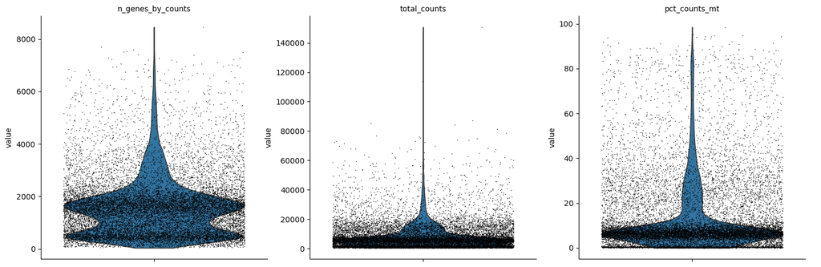

```python
# sc.pl is the plots module
sc.pl.violin(
    adata,
    ["n_genes_by_counts", "total_counts", "pct_counts_mt"],
    jitter=0.4,
    multi_panel=True,
)
```

Looks like we can look at these together in a scatterplot

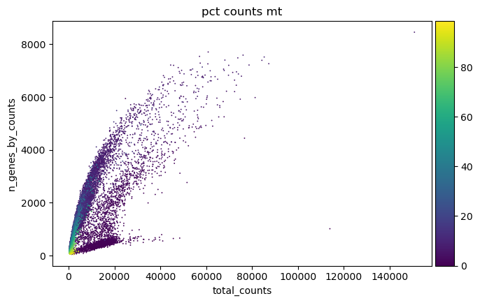

```python
sc.pl.scatter(adata, "total_counts", "n_genes_by_counts", color="pct_counts_mt")
```

From the tutorial:

```
Based on the QC metric plots, one could now remove cells that have too many mitochondrial genes expressed or too many total counts by setting manual or automatic thresholds. However, sometimes what appears to be poor QC metrics can be driven by real biology so we suggest starting with a very permissive filtering strategy and revisiting it at a later point. We therefore now only filter cells with less than 100 genes expressed and genes that are detected in less than 3 cells.

Additionally, it is important to note that for datasets with multiple batches, quality control should be performed for each sample individually as quality control thresholds can vary substantially between batches.
```

Why filter out things with too many mitochondrial genes? -- looks like this could potentially be due to cells dying/in stress -- mitochondria may still be intact, meaning that more mitochondrial dna is still around than nuclear.

```python
sc.pp.filter_cells(adata, min_genes=100)
sc.pp.filter_genes(adata, min_cells=3)
adata
```

```
AnnData object with n_obs × n_vars = 17041 × 23427
    obs: 'sample', 'n_genes_by_counts', 'log1p_n_genes_by_counts', 'total_counts', 'log1p_total_counts', 'pct_counts_in_top_50_genes', 'pct_counts_in_top_100_genes', 'pct_counts_in_top_200_genes', 'pct_counts_in_top_500_genes', 'total_counts_mt', 'log1p_total_counts_mt', 'pct_counts_mt', 'total_coun…
    var: 'mt', 'ribo', 'hb', 'n_cells_by_counts', 'mean_counts', 'log1p_mean_counts', 'pct_dropout_by_counts', 'total_counts', 'log1p_total_counts', 'n_cells'
```

## Doublet detection

Not sure how relevant this will be to our analysis, as probe based scrna seq is resilient to doublets and actually can make use of that to get a higher quantity of data, but maybe this means that we will have to be even more conscientous of this and follow a different approach in order to parse out and properly handle the (frequent) doublets that we should be seeing.

Note -- this step seems to take a bit longer than everything else we've done so far.

```python
sc.pp.scrublet(adata, batch_key="sample")
adata
```

```
AnnData object with n_obs × n_vars = 17041 × 23427
    obs: 'sample', 'n_genes_by_counts', 'log1p_n_genes_by_counts', 'total_counts', 'log1p_total_counts', 'pct_counts_in_top_50_genes', 'pct_counts_in_top_100_genes', 'pct_counts_in_top_200_genes', 'pct_counts_in_top_500_genes', 'total_counts_mt', 'log1p_total_counts_mt', 'pct_counts_mt', 'total_coun…
    var: 'mt', 'ribo', 'hb', 'n_cells_by_counts', 'mean_counts', 'log1p_mean_counts', 'pct_dropout_by_counts', 'total_counts', 'log1p_total_counts', 'n_cells'
    uns: 'scrublet'
```

## Normalization

Now onto normalization.

From the tutorial:

```
The next preprocessing step is normalization. A common approach is count depth scaling with subsequent log plus one (log1p) transformation. Count depth scaling normalizes the data to a “size factor” such as the median count depth in the dataset, ten thousand (CP10k) or one million (CPM, counts per million). The size factor for count depth scaling can be controlled via target_sum in pp.normalize_total. We are applying median count depth normalization with log1p transformation (AKA log1PF).
```

From [10X genomics](https://www.10xgenomics.com/analysis-guides/single-cell-rna-seq-data-normalization):

```
The size-factor normalization reduces the technical variation from sequencing depth, while the log transformation minimizes the effects from expression outliers and helps prevent high-abundance genes from dominating downstream analysis due to their higher technical variability.
```

However, this can lead to some biases and makes some assumptions that aren't necessarily the best. More options are listed in the 10x Genomics link above, but they all are in R. Should check in at our meeting to see if it is worth exploring other options for this.

```python
# Saving count data
adata.layers["counts"] = adata.X.copy()
```

```python
# Normalizing to median total counts
sc.pp.normalize_total(adata)
# Logarithmize the data
sc.pp.log1p(adata)
```

## Feature selection

Cool, now let's do some filtering for the most informative genes. This is done through `pp.highly_variable_genes()`, and allows for multiple different implementations depending on the `flavor` apparently, but they don't actually seem to specify one in the tutorial, so it's going with the default, `seurat`, based on [Satija 2015](https://doi.org/10.1038/nbt.3192). There are a bunch of options here -- we should ask if there are any which they prefer here. Some require installation of more dependencies which may or may not be in this conda environment.

```python
sc.pp.highly_variable_genes(adata, n_top_genes=2000, batch_key="sample")
```

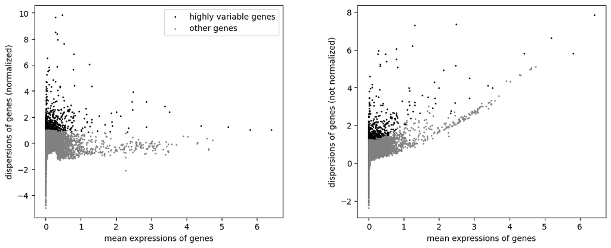

```python
# and now plotting it..
sc.pl.highly_variable_genes(adata)
```

## PCA

Sick.. time for our PCA.

```python
# sc.tl is the "tools" module
sc.tl.pca(adata)
```

We can look at the contributions of the different principle components to our variance like so:

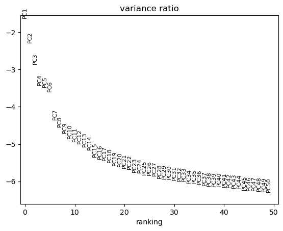

```python
sc.pl.pca_variance_ratio(adata, n_pcs=50, log=True)
```

And we can plot it too. They say that this is to check for batch effects or quality control metrics driving significant variation in the dataset.. curious as to what we would want to be looking out for in that scenario.

Plot it like so:

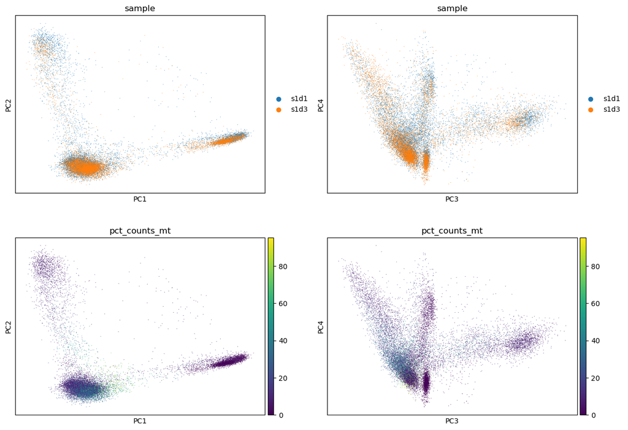

```python
sc.pl.pca(
    adata,
    color=["sample", "sample", "pct_counts_mt", "pct_counts_mt"],
    dimensions=[(0, 1), (2, 3), (0, 1), (2, 3)],
    ncols=2,
    size=2,
)
```

## Nearest neighbors/UMAP time

Alright.. I don't really understand UMAP all that well so I took a look at [this interactive explanation](https://pair-code.github.io/understanding-umap/).

Essentially we are building a graph of probability that data points are connected. This is done by taking points, and finding the nth nearest neighbors based on a distance and n. Some additional things:

- The likelihood that two points are connected decreases with an increased radius
- Each point must be in contact with at least its nearest neighbor -- keeps balance of local vs global structure

Then, a low-dimension analogue is optimized (stochastically). Don't really get how. The paper is comparing UMAP to t-SNE but that doesn't really help since I don't know what that is. Oh.. looks like it's essentially using KL divergence as the metric for optimization? I think I presented on this a few years ago for a math class but I have since forgotten the details.. essential it's statistical distance measuring entropy between two distributions.

Important to remember here is that we've got two hyperparameters which seriously shape how this gets processed down the line which need tuning:

- number of neighbors (most important)
- distance

Anyways... here's how to do it (using default parameters -- `n_neighbors = 15` in `sc.pp.neigbors()`, `min_dist = 0.5` in `sc.tl.umap()`).

```python
# start with getting the neighbors graph
sc.pp.neighbors(adata)
```

```python
# and umaping it
sc.tl.umap(adata)
```

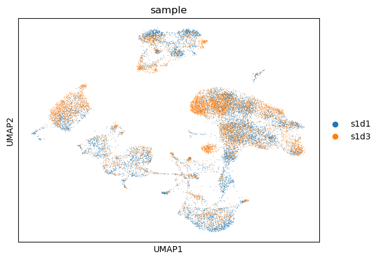

```python
# and now plotting it
sc.pl.umap(
    adata,
    color="sample",
    # Setting a smaller point size to get prevent overlap
    size=2,
)
```

Looks like there is a small batch effect here, but nothing to worry about. If it is something to worry about down the road, the tutorial recommends scanorama and [scvi-tools](https://scvi-tools.org/) for batch correction/integration.

## Clustering

Seems like they recommend the Leiden graph-clustering method.. should look into this to see more about how it works, but it operates based off of the neighborhood graph we already made.

```python
# Using the igraph implementation and a fixed number of iterations can be significantly faster, especially for larger datasets
sc.tl.leiden(adata, flavor="igraph", n_iterations=2)
```

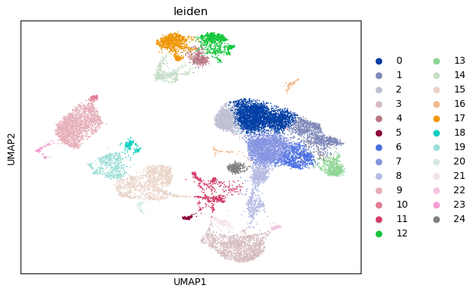

```python
# and plotting it
sc.pl.umap(adata, color=["leiden"])
```

And now to reexamine our quality control filtering through visualizations with UMAP.

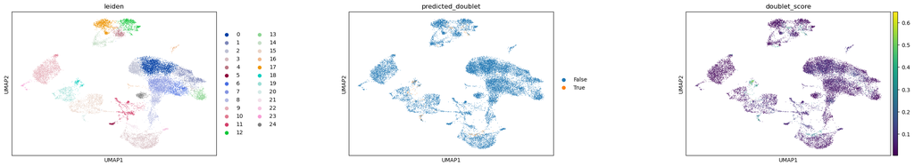

```python
sc.pl.umap(
    adata,
    color=["leiden", "predicted_doublet", "doublet_score"],
    # increase horizontal space between panels
    wspace=0.5,
    size=3,
)
```

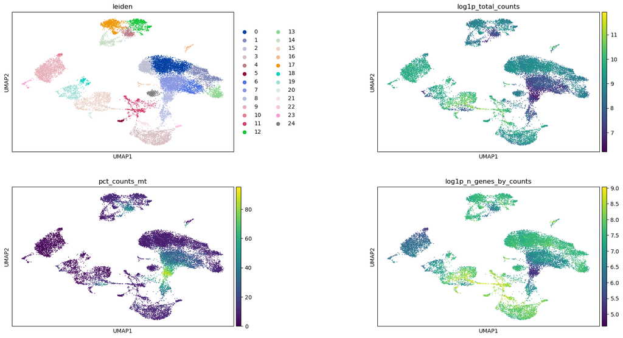

```python
sc.pl.umap(
    adata,
    color=["leiden", "log1p_total_counts", "pct_counts_mt", "log1p_n_genes_by_counts"],
    wspace=0.5,
    ncols=2,
)
```

Welp.. didn't actually make any comments about how good this looks so time to look into the literature/ask questions of mentors.

Moving on to cell-type annotation.

```python
## Cell type annotation
```